# Питон для астрономов

## Часть вторая

## Александр Марчук

# Еще немного про пакеты

# Pandas

http://pandas.pydata.org/

```python
import pandas
print pandas.__doc__
```

```
pandas - a powerful data analysis and manipulation library for Python
=====================================================================

See http://pandas.pydata.org/ for full documentation. Otherwise, see the
docstrings of the various objects in the pandas namespace:

Series
DataFrame
Panel
Index
DatetimeIndex
HDFStore
bdate_range
date_range
read_csv
read_fwf
read_table
ols
```

# Seaborn

https://web.stanford.edu/~mwaskom/software/seaborn/

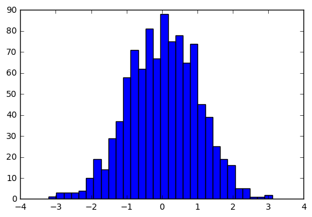

```python
%matplotlib inline
import numpy as np
import matplotlib.pyplot as plt
import matplotlib

y = np.random.normal(loc=0.0, scale=1.0, size=1000)

plt.hist(y, 30)
plt.show()
```

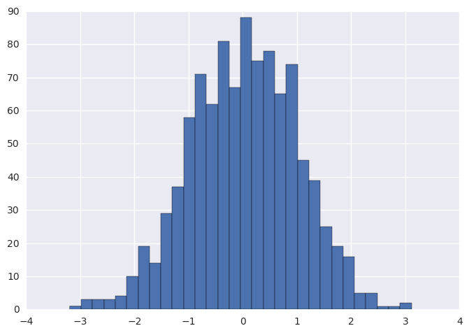

```python
import seaborn as sns

sns.set(style="darkgrid")
plt.hist(y, 30)
plt.show()
```

# scikit-learn

http://scikit-learn.org/

# AstroPy

http://www.astropy.org/

Лучший сайт на мой взгляд о питоне для астрономов:  
http://www.astropython.org/

Python for Astronomers The purpose of this web site is to act as a community knowledge base for performing astronomy research with Python. It provides a variety of tutorials, code snippets, resources, lists of useful packages, general discussion, advice and also features news items, event information and announcements.

Еще неплохой блог:  
http://www.astrobetter.com/ 'Tips and Tricks for Professional Astronomers'

Книга:  
Numerical Methods in Engineering with Python  
by Jaan Kiusalaas

[figure not shown]

# Установщики пакетов

#### pip

```
$: pip install some-package-name
```

#### easy_install

```
$: easy_install numpy
```

#### Anaconda

приз зрительских моих симпатий

```
$: conda install seaborn
```

Установщики внутри различных IDE (далее, например Pycharm)

#### Windows:

[figure not shown]

все то же самое, но если что-то не работает - бинарные пакеты собраны на http://www.lfd.uci.edu/~gohlke/pythonlibs/

## еще немного про синтаксис...

# Словари

```python
dna_bricks = {'A' : 'adenine', 'G' : 'guanine', 'C' : 'cytosine', 'T' : 'thymine'}
dna_pair = {'A' : 'T', 'T' : 'A', 'G' : 'C', 'C' : 'G'}
#CD28 human gene
dna = 'TAAAGTCATCAAAA'
```

```python
for brick in dna:
    print '%s --- %s' % (brick, dna_pair[brick])
```

```
T --- A
A --- T
A --- T
A --- T
G --- C
T --- A
C --- G
A --- T
T --- A
C --- G
A --- T
A --- T
A --- T
A --- T
```

```python
dna_bricks.keys()
```

```
['A', 'C', 'T', 'G']
```

```python
dna_bricks.values()
```

```
['adenine', 'cytosine', 'thymine', 'guanine']
```

```python
dna_bricks.items()
```

```
[('A', 'adenine'), ('C', 'cytosine'), ('T', 'thymine'), ('G', 'guanine')]
```

```python
dna_bricks.update([('U', 'uracil')])
print dna_bricks
```

```
{'A': 'adenine', 'C': 'cytosine', 'U': 'uracil', 'T': 'thymine', 'G': 'guanine'}
```

Cygnus

```python
print canstellation_rus['Cygnus']
```

```
Лебедь
```

Cetus

```python
print canstellation_rus['Cetus']
```

```
Кит
```

Ursa Major

```python
print canstellation_rus['Ursa Major']
```

```
Большая Медведица
```

Sagittarius

```python
print canstellation_rus['Sagittarius']
```

```
Стрелец
```

# Лямбда-выражения

$V = I\times\ln\frac{M_{total}}{M}$

```python
v = 7.9 #km/s
m = 1   #kg

fmass = lambda l: np.exp(v/l)*m - m
print fmass(3.5)
```

```
8.55574798943
```

Применение к массиву/списку/кортежу/etc:

```python
fuel = {'solid' : 3.0, 'Kerosene-O' : 3.1, 'Methane-O' : 3.4, 'H-O' : 4.5}
print map(fmass, fuel.values())
```

```
[12.920092964015097, 9.211651903213335, 4.7866616611527535, 11.786463813269842]
```

```python
zip(map(fmass, fuel.values()), fuel.keys())
```

```
[(12.920092964015097, 'solid'),
 (9.211651903213335, 'Methane-O'),
 (4.7866616611527535, 'H-O'),
 (11.786463813269842, 'Kerosene-O')]
```

# Генераторы списков

### (они же list comprehension)

```python
range(10)**7
```

```
---------------------------------------------------------------------------
TypeError                                 Traceback (most recent call last)
<ipython-input-18-8b29631f237b> in <module>()
----> 1 range(10)**7

TypeError: unsupported operand type(s) for ** or pow(): 'list' and 'int'
```

```python
pow7 = lambda l: l**7
map(pow7, range(10))
```

```
[0, 1, 128, 2187, 16384, 78125, 279936, 823543, 2097152, 4782969]
```

```python
[q**7 for q in range(10)]
```

```
[0, 1, 128, 2187, 16384, 78125, 279936, 823543, 2097152, 4782969]
```

```python
{a : a**7 for a in range(5)}
```

```
{0: 0, 1: 1, 2: 128, 3: 2187, 4: 16384}
```

# IDEs

Среда для разработки

# Python(x,y)/Spyder

[figure not shown]

# IEP (Pyzo)

[figure not shown]

# PyDev

[figure not shown]

# Enthought Canopy

[figure not shown]

# Pycharm

[figure not shown]

# Pycharm Edu

[figure not shown]

Тысячи их других:

- gedit
- Notepad++
- emacs
- vim
- sublime
- Python Tools for Visual Studio
- etc.

# И наконец - IPython!

### Хотя это совсем не IDE

- Похоже на Matlab, интерактивная оболочка
- Куча плюшек, которых нет в оригинальном языке - самые вкусные это автодополнение и табуляция
- "Магия". Серьезно, magic commands

```python
lsmagic
```

```
Available line magics:
%alias  %alias_magic  %autocall  %automagic  %autosave  %bookmark  %cd  %clear  %cls  %colors  %config  %connect_info  %copy  %ddir  %debug  %dhist  %dirs  %doctest_mode  %echo  %ed  %edit  %env  %gui  %hist  %history  %killbgscripts  %ldir  %less  %load  %load_ext  %loadpy  %logoff  %logon  %logsta…

Available cell magics:
%%!  %%HTML  %%SVG  %%bash  %%capture  %%cmd  %%debug  %%file  %%html  %%javascript  %%js  %%latex  %%perl  %%prun  %%pypy  %%python  %%python2  %%python3  %%ruby  %%script  %%sh  %%svg  %%sx  %%system  %%time  %%timeit  %%writefile

Automagic is ON, % prefix IS NOT needed for line magics.
```

```python
%timeit range(10)
```

```
1000000 loops, best of 3: 201 ns per loop
```

## Но можно и еще лучше: IPython Notebook

По сути, интерактивный питон в браузере, с модульностью, магией, поддержкой $\TeX$, html и гитхабовской разметки, вставкой картинок и видео, интерактивными виджетами и т.д. и т.п. Его даже можно превратить в статью ApJ! И, как правило, не надо запускать всю программу за раз при малом изменении.

$$\left\{ \begin{array}{lr} \sigma_{los,maj}^2(R_j)\times \sigma_{min,0}^2 =\sigma_{los,min}^2(R_j)[Af(R_j)+B]\\ \sigma_{min,0}^2=A+B \end{array} \right. $$

```
<function __main__.plot_sine>
```

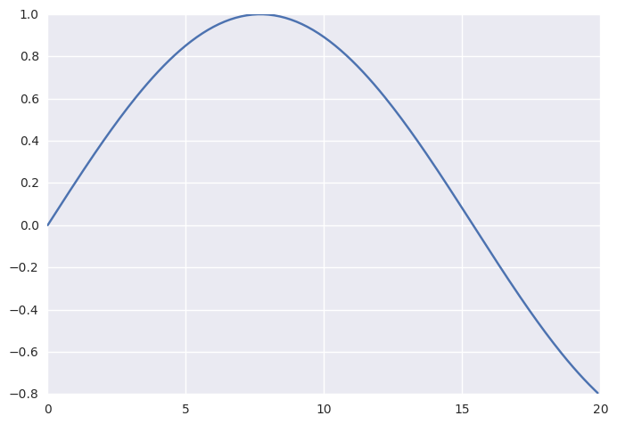

```python
from IPython.html.widgets import interact
def plot_sine(n):
    x = np.arange(0, 20, 0.1);
    y = np.sin(x/n)
    plt.plot(x, y)
interact(plot_sine, n=(1,10, 0.1))
```

Как запустить ipython notebook? А так и запустить

```
$: ipython notebook
```

И тогда в командной строке появится что-то вроде этого:

```
[NotebookApp] Using existing profile dir: u'/home/gus/.ipython/profile_default'
[NotebookApp] Serving notebooks from /home/gus/workshops
[NotebookApp] The IPython Notebook is running at: http://127.0.0.1:8888/
[NotebookApp] Use Control-C to stop this server and shut down all kernels.
```

А в браузере - это:

[figure not shown]

(и сейчас мы смотрим на ноутбук)

# Кто на чем пишет из астрономов

#### пруф с прошлой лекции

Software Use in Astronomy: an Informal Survey

Ivelina Momcheva, Erik Tollerud

http://arxiv.org/abs/1507.03989

[figure not shown]

# Произношение

[figure not shown]

# Performance

## чтобы не быть голословным:

[figure not shown]

### The Computer Language Benchmarks Game

https://benchmarksgame.alioth.debian.org/

```python
from IPython.display import HTML
HTML('<iframe src=https://benchmarksgame.alioth.debian.org/u64q/performance.php?test=nbody&sort=elapsed width=1000 height=350></iframe>')
```

[interactive chart not shown]

# Другие интерпретаторы

## (для любителей разных фломастеров)

- CPython
- Cython
- Jyton
- PyPy
- IronPython and PythonNet

## Что написано на Python-е

- Youtube
- Dropbox
- Quora
- Instagram
- BitTorrent (Earlier Version)
- Spotify
- Reddit
- Pinterest
- BitBucket
- Blender3D
- EVE Online MMOPG
- Mercurial Source Control
- Wicd

```
$: ipython nbconvert Python_Lecture2.ipynb --to slides --post serve
```

# Вопросы?

```python
def gasket(pa, pb, pc, level):
    '''
    GASKET Recursively generated Sierpinski gasket.
    GASKET(PA, PB, PC, LEVEL) generates an approximation to
    the Sierpinski gasket, where the 2-vectors PA, PB, and PC Z define the triangle vertices.
    LEVEL is the level of recursion.
    '''
    if level == 0:
        # Fill the triangle with vertices Pa, Pb, Pc.
        plt.fill([pa[0], pb[0], pc[0]], [pa[1], pb[1], pc[1]], 'g')
    else:
        # Recursive calls for the three subtriangles.
        gasket(pa, (pa + pb) / 2., (pa + pc) / 2., level - 1)
        gasket(pb, (pb + pa) / 2., (pb + pc) / 2., level - 1)
        gasket(pc, (pc + pa) / 2., (pc + pb) / 2., level - 1)
```

```
(0.0, 1.0, 0.0, 0.90000000000000002)
```

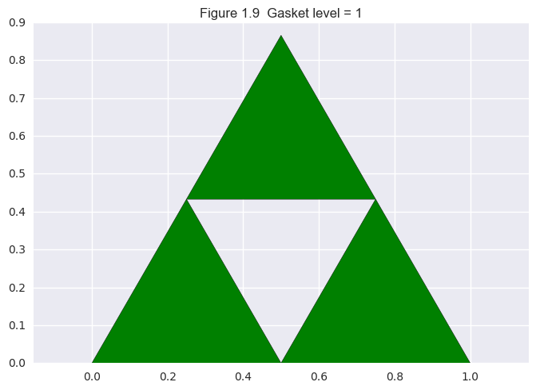

```python
pa = np.array([0, 0])
pb = np.array([1, 0])
pc = np.array([0.5, np.sqrt(3)/2.])
level = 1
gasket(pa, pb, pc, level)
plt.title("Figure 1.9  Gasket level = 1")
plt.axis('equal')
```

```
(0.0, 1.0, 0.0, 0.90000000000000002)
```

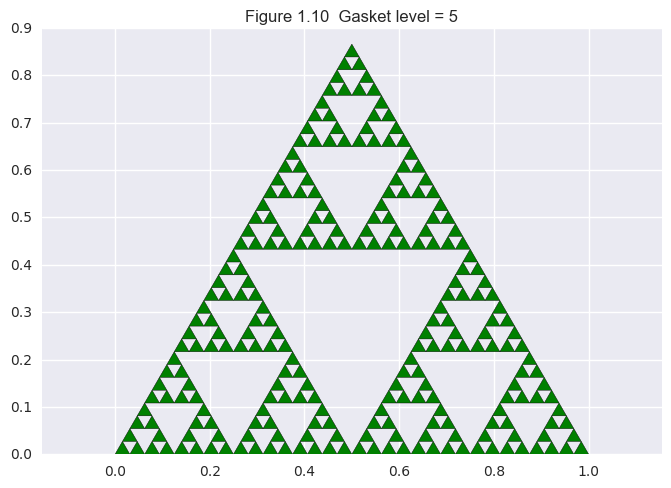

```python
level = 5
gasket(pa, pb, pc, level)
plt.title("Figure 1.10  Gasket level = 5")
plt.axis('equal')
```

# Просмотр Notebooks

https://nbviewer.jupyter.org/

```python
HTML('<iframe src=https://nbviewer.jupyter.org/ width=1200 height=450></iframe>')
```

[interactive chart not shown]

## Например, LIGO Signal Processing Notebook

https://losc.ligo.org/s/events/GW150914/GW150914_tutorial.html

```python
HTML('<iframe src=https://losc.ligo.org/s/events/GW150914/GW150914_tutorial.html width=1200 height=450></iframe>')
```

[interactive chart not shown]

https://nbviewer.jupyter.org/github/Amarchuk/2FInstability

```python
HTML('<iframe src=https://nbviewer.jupyter.org/github/Amarchuk/2FInstability/blob/master/notebooks/2f/n3898.ipynb width=1200 height=450></iframe>')
```

[interactive chart not shown]

# Всё

[figure not shown]